# Was turnout associated with the composition of Labour, Tory, and Reform votes in the 2024 UK general election?

Andi Fugard (Mastodon: @andi@sciences.social)

31 July 2024

This is an excuse to try out the {compos} package, by David Firth and Fiona Sammut, using [data](https://commonslibrary.parliament.uk/research-briefings/cbp-10009/) from the House of Commons Library, published 18 July.

Load up some packages ({compos} isn’t on CRAN yet):

```r
#devtools::install_github("DavidFirth/compos")
library(compos)
library(conflicted)
library(tidyverse)
library(ggmice)
library(mice)
library(table1)
library(marginaleffects)
```

## Setup the data

Candidate-level data:

```r
ge_dat <- read_csv("HoC-GE2024-results-by-candidate.csv")
```

Constituency-level data, used for the turnout figures:

```r
ge_turnout <- read_csv("HoC-GE2024-results-by-constituency.csv") |>
  mutate(turnout_percentage = 100*`Valid votes`/Electorate) |>
  select(`Constituency name`, turnout_percentage) |>
  rename(constituency = `Constituency name`)
ge_turnout
```

| constituency | turnout_percentage |
| --- | --- |
| Aberafan Maesteg | 49.26288 |
| Aberdeen North | 55.44287 |
| Aberdeen South | 59.93301 |
| Aberdeenshire North and Moray East | 54.50912 |
| Airdrie and Shotts | 52.23151 |
| Aldershot | 61.79777 |
| Aldridge-Brownhills | 58.22280 |
| Alloa and Grangemouth | 58.29230 |
| Altrincham and Sale West | 69.50625 |
| Alyn and Deeside | 57.25294 |

[output cut: 640 more lines]

Filter so we only have Labour, Tory, and Reform, join on the turnout, and pivot wider with all the data we want (also fix one typo in the data, which I’ve notified Commons Library about):

```r
parties <- c("Lab", "Con", "RUK")

simp_dat <- ge_dat |>
  dplyr::filter(`Party abbreviation` %in% parties) |>
  select(`Constituency name`, `Party abbreviation`, Votes) |>
  mutate(
    `Constituency name` = ifelse(
      `Constituency name` == "YeoYeovil",
      "Yeovil",
      `Constituency name`
    )
  ) |>
  pivot_wider(names_from = `Party abbreviation`, values_from = "Votes") |>
  rename(constituency = `Constituency name`) |>
  left_join(ge_turnout)
simp_dat
```

| constituency | Con | RUK | Lab | turnout_percentage |
| --- | --- | --- | --- | --- |
| Aberafan Maesteg | 2903 | 7484 | 17838 | 49.26288 |
| Aberdeen North | 5881 | 3781 | 12773 | 55.44287 |
| Aberdeen South | 11300 | 3199 | 11455 | 59.93301 |
| Aberdeenshire North and Moray East | 12513 | 5562 | 3876 | 54.50912 |
| Airdrie and Shotts | 1696 | 2971 | 18871 | 52.23151 |
| Aldershot | 14081 | 8210 | 19764 | 61.79777 |
| Aldridge-Brownhills | 15901 | 9903 | 11607 | 58.22280 |
| Alloa and Grangemouth | 3127 | 3804 | 18039 | 58.29230 |
| Altrincham and Sale West | 16624 | 4961 | 20798 | 69.50625 |
| Alyn and Deeside | 7892 | 9601 | 18395 | 57.25294 |

[output cut: 626 more lines]

```r
table1( ~ ., data = simp_dat |> dplyr::select(-constituency))
```

|  | Overall (N=636) |
| --- | --- |
| Con |  |
| Mean (SD) | 10800 (5580) |
| Median [Min, Max] | 11400 [46.0, 25500] |
| Missing | 1 (0.2%) |
| RUK |  |
| Mean (SD) | 6760 (2750) |
| Median [Min, Max] | 7050 [697, 21200] |
| Missing | 27 (4.2%) |
| Lab |  |
| Mean (SD) | 15400 (5670) |
| Median [Min, Max] | 16200 [1490, 29200] |
| Missing | 5 (0.8%) |
| turnout_percentage |  |
| Mean (SD) | 59.8 (6.92) |
| Median [Min, Max] | 60.1 [40.0, 79.2] |

Missingness:

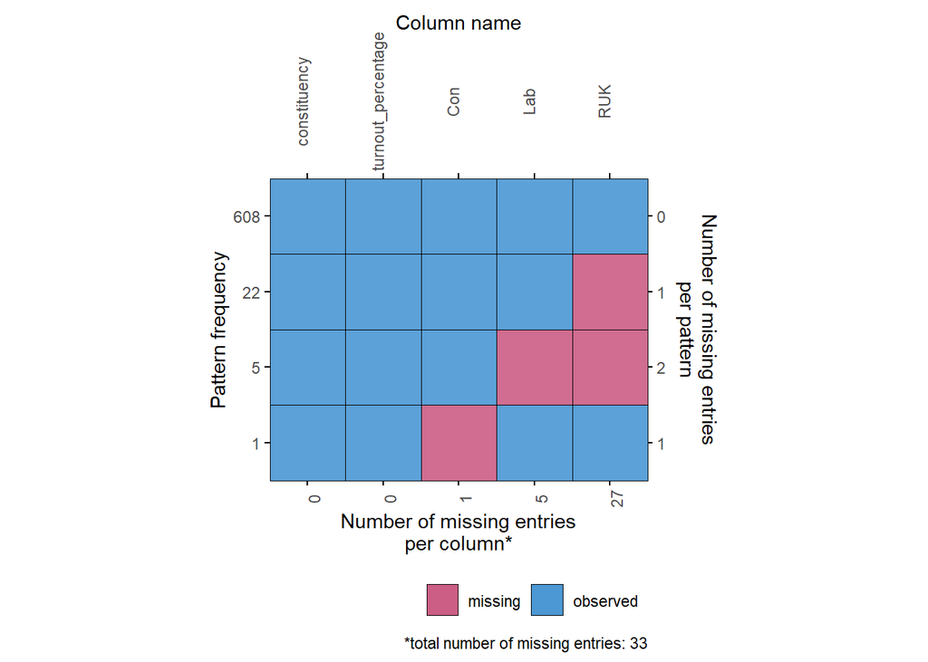

```r
plot_pattern(simp_dat, rotate = TRUE)
```

```r
names(simp_dat)
```

```
## [1] "constituency"       "Con"                "RUK"
## [4] "Lab"                "turnout_percentage"
```

Zap all the rows with any missing data (e.g., because Reform didn’t stand a candidate).

```r
for_analy_counts <- na.omit(simp_dat)
table1( ~ ., data = for_analy_counts |> dplyr::select(-constituency))
```

|  | Overall (N=608) |
| --- | --- |
| Con |  |
| Mean (SD) | 10800 (5460) |
| Median [Min, Max] | 11500 [586, 25500] |
| RUK |  |
| Mean (SD) | 6750 (2750) |
| Median [Min, Max] | 7050 [697, 21200] |
| Lab |  |
| Mean (SD) | 15400 (5660) |
| Median [Min, Max] | 16100 [1490, 29200] |
| turnout_percentage |  |
| Mean (SD) | 60.0 (6.84) |
| Median [Min, Max] | 60.4 [40.0, 79.2] |

Create another dataframe with percentages, conditional on voting for one of these three parties.

```r
perc <- for_analy_counts |>
  pivot_longer(names_to = "Party",
               values_to = "Votes",
               cols = Con:Lab) |>
  group_by(constituency) |>
  mutate(Perc = 100 * Votes / sum(Votes))
perc
```

| constituency | turnout_percentage | Party | Votes | Perc |
| --- | --- | --- | --- | --- |
| Aberafan Maesteg | 49.26288 | Con | 2903 | 10.285208 |
| Aberafan Maesteg | 49.26288 | RUK | 7484 | 26.515500 |
| Aberafan Maesteg | 49.26288 | Lab | 17838 | 63.199291 |
| Aberdeen North | 55.44287 | Con | 5881 | 26.213506 |
| Aberdeen North | 55.44287 | RUK | 3781 | 16.853131 |
| Aberdeen North | 55.44287 | Lab | 12773 | 56.933363 |
| Aberdeen South | 59.93301 | Con | 11300 | 43.538568 |
| Aberdeen South | 59.93301 | RUK | 3199 | 12.325653 |
| Aberdeen South | 59.93301 | Lab | 11455 | 44.135779 |
| Aberdeenshire North and Moray East | 54.50912 | Con | 12513 | 57.004237 |

[output cut: 1814 more lines]

## Have a look

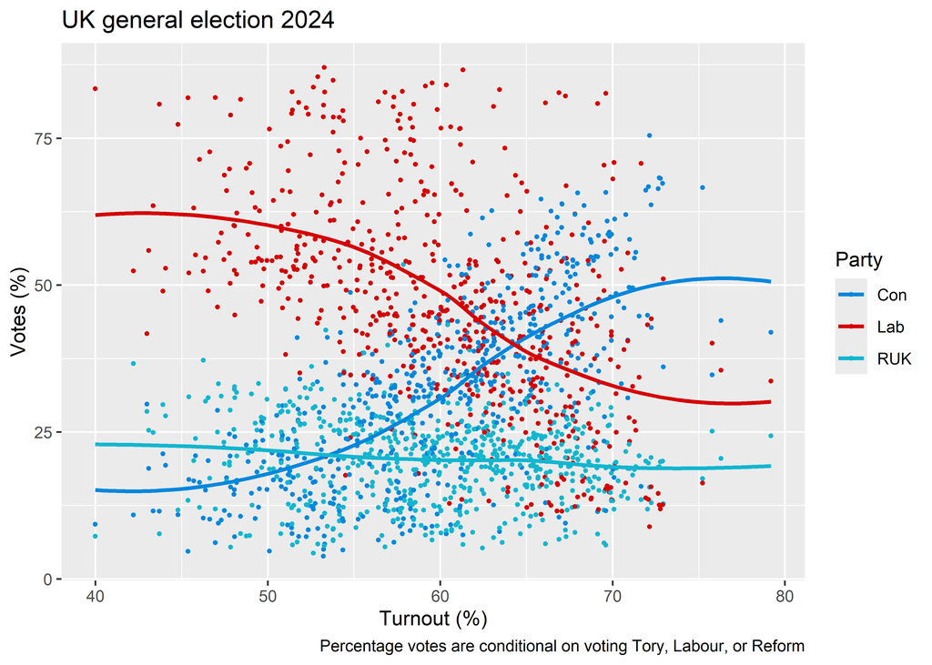

```r
plot_votes <- perc |>
  ggplot(aes(turnout_percentage, Perc, colour = Party)) +
  geom_point(size = .7) +
  labs(
    x = "Turnout (%)",
    y = "Votes (%)",
    title = "UK general election 2024",
    caption = "Percentage votes are conditional on voting Tory, Labour, or Reform"
  ) +
  scale_color_manual(values = c("#0087dc", "#d50000", "#12b6cf"))
plot_votes +
  geom_smooth(se = FALSE,
              method = "loess",
              formula = y ~ x)
```

## Modelling

### Fit the models using the original counts

Now, onto the modelling. These use the generalized Wedderburn logit model.

```r
mod1_count <- colm(cbind(Con, Lab, RUK) ~ turnout_percentage, ref = 1, data = for_analy_counts)
mod2_count <- colm(cbind(Con, Lab, RUK) ~ turnout_percentage, ref = 2, data = for_analy_counts)
mod3_count <- colm(cbind(Con, Lab, RUK) ~ turnout_percentage, ref = 3, data = for_analy_counts)
```

```r
short_sum <- function(mod) {
  (mod |> summary())$Coefficients
}
```

```r
mod1_count |> short_sum()
```

```
##    Lab / Con :
##                    Estimate  St. err
## (Intercept)         5.13500 0.243600
## turnout_percentage -0.07861 0.004036
##
##    RUK / Con :
##                    Estimate  St. err
## (Intercept)         2.93800 0.149500
## turnout_percentage -0.05564 0.002477
```

```r
mod2_count |> short_sum()
```

```
##    Con / Lab :
##                    Estimate  St. err
## (Intercept)        -5.13500 0.243600
## turnout_percentage  0.07861 0.004036
##
##    RUK / Lab :
##                    Estimate  St. err
## (Intercept)        -2.19800 0.230800
## turnout_percentage  0.02297 0.003823
```

```r
mod3_count |> short_sum()
```

```
##    Con / RUK :
##                    Estimate  St. err
## (Intercept)        -2.93800 0.149500
## turnout_percentage  0.05564 0.002477
##
##    Lab / RUK :
##                    Estimate  St. err
## (Intercept)         2.19800 0.230800
## turnout_percentage -0.02297 0.003823
```

The estimates/SE for turnout are around 20 for the comparisons of Labour versus Conservative and Reform versus conservative. They are around 6 for Labour versus Reform. So, all “statistically significant”.

Now the coefficients. Choose the first model:

```r
bs <- mod1_count |> coef()
bs
```

```
##                    Con         Lab         RUK
## (Intercept)          0  5.13542079  2.93753844
## turnout_percentage   0 -0.07860971 -0.05563858
```

These are as easy to interpret as logistic regression coefficients ;-) One trick is to exp them to get odds ratios.

```r
bs |> exp() |> round(2)
```

```
##                    Con    Lab   RUK
## (Intercept)          1 169.94 18.87
## turnout_percentage   1   0.92  0.95
```

The intercepts give the odds of voting each party rather than Conservative when turnout is zero, which probably isn’t useful… Each percentage point increase in turnout reduces the odds of voting Labour by 8% compared to Conservative.

It’s easier to plot them:

```r
lab_vs_con_pred <- function(t)
  exp(bs["(Intercept)", "Lab"] + bs["turnout_percentage", "Lab"] * t)
ref_vs_con_pred <- function(t)
  exp(bs["(Intercept)", "RUK"] + bs["turnout_percentage", "RUK"] * t)
con_vs_con_pred <- function(t)
  exp(bs["(Intercept)", "Con"] + bs["turnout_percentage", "Con"] * t)

lab_pred <- function(turnout)
  100 * lab_vs_con_pred(turnout) /
  (lab_vs_con_pred(turnout) + con_vs_con_pred(turnout) + ref_vs_con_pred(turnout))
con_pred <- function(turnout)
  100 * con_vs_con_pred(turnout) /
  (lab_vs_con_pred(turnout) + con_vs_con_pred(turnout) + ref_vs_con_pred(turnout))
ref_pred <- function(turnout)
  100 * ref_vs_con_pred(turnout) /
  (lab_vs_con_pred(turnout) + con_vs_con_pred(turnout) + ref_vs_con_pred(turnout))
```

Note the Conservative predictions, since it is the base category with intercept and slope of zero:

```r
con_vs_con_pred(seq(0, 100, 10))
```

```
##  [1] 1 1 1 1 1 1 1 1 1 1 1
```

(I wanted to follow the recipe rather than just add a constant.)

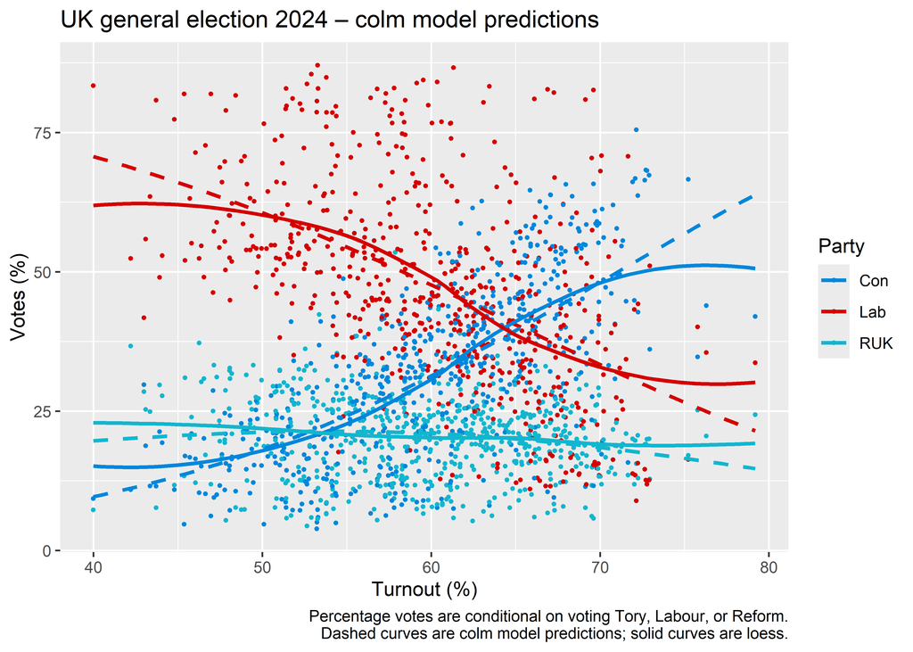

```r
plot_votes +
  geom_function(
    fun = lab_pred,
    colour = "#d50000",
    linewidth = 1,
    linetype = "dashed"
  ) +
  geom_function(
    fun = con_pred,
    colour = "#0087dc",
    linewidth = 1,
    linetype = "dashed"
  ) +
  geom_function(
    fun = ref_pred,
    colour = "#12b6cf",
    linewidth = 1,
    linetype = "dashed"
  ) +
  labs(title = "UK general election 2024 – colm model predictions",
       caption = "Percentage votes are conditional on voting Tory, Labour, or Reform.\nDashed curves are colm model predictions; solid curves are loess.") +
  geom_smooth(se = FALSE,
              method = "loess",
              formula = y ~ x)
```

The loess curve looks more sigmoid-shaped than the colm fit.

### Try again with percentages

If I’ve understood the model correctly, then using the percentages as outcomes, rather than counts, should give the same model coefficients and standard errors:

```r
for_analy_percs <- perc |>
  select(-Votes) |>
  pivot_wider(names_from = "Party",
              values_from = "Perc")
for_analy_percs
```

| constituency | turnout_percentage | Con | RUK | Lab |
| --- | --- | --- | --- | --- |
| Aberafan Maesteg | 49.26288 | 10.285208 | 26.515500 | 63.199291 |
| Aberdeen North | 55.44287 | 26.213506 | 16.853131 | 56.933363 |
| Aberdeen South | 59.93301 | 43.538568 | 12.325653 | 44.135779 |
| Aberdeenshire North and Moray East | 54.50912 | 57.004237 | 25.338253 | 17.657510 |
| Airdrie and Shotts | 52.23151 | 7.205370 | 12.622143 | 80.172487 |
| Aldershot | 61.79777 | 33.482345 | 19.522054 | 46.995601 |
| Aldridge-Brownhills | 58.22280 | 42.503542 | 26.470824 | 31.025634 |
| Alloa and Grangemouth | 58.29230 | 12.523028 | 15.234281 | 72.242691 |
| Altrincham and Sale West | 69.50625 | 39.223273 | 11.705165 | 49.071562 |
| Alyn and Deeside | 57.25294 | 21.990638 | 26.752675 | 51.256687 |

[output cut: 598 more lines]

```r
mod1_perc <- colm(cbind(Con, Lab, RUK) ~ turnout_percentage,
                  ref = 1,
                  data = for_analy_percs)
mod2_perc <- colm(cbind(Con, Lab, RUK) ~ turnout_percentage,
                  ref = 2,
                  data = for_analy_percs)
mod3_perc <- colm(cbind(Con, Lab, RUK) ~ turnout_percentage,
                  ref = 3,
                  data = for_analy_percs)
```

Reference level Con:

```r
mod1_count |> short_sum()
```

```
##    Lab / Con :
##                    Estimate  St. err
## (Intercept)         5.13500 0.243600
## turnout_percentage -0.07861 0.004036
##
##    RUK / Con :
##                    Estimate  St. err
## (Intercept)         2.93800 0.149500
## turnout_percentage -0.05564 0.002477
```

```r
mod1_perc  |> short_sum()
```

```
##    Lab / Con :
##                    Estimate  St. err
## (Intercept)         5.13500 0.243600
## turnout_percentage -0.07861 0.004036
##
##    RUK / Con :
##                    Estimate  St. err
## (Intercept)         2.93800 0.149500
## turnout_percentage -0.05564 0.002477
```

Reference level Lab:

```r
mod2_count |> short_sum()
```

```
##    Con / Lab :
##                    Estimate  St. err
## (Intercept)        -5.13500 0.243600
## turnout_percentage  0.07861 0.004036
##
##    RUK / Lab :
##                    Estimate  St. err
## (Intercept)        -2.19800 0.230800
## turnout_percentage  0.02297 0.003823
```

```r
mod2_perc  |> short_sum()
```

```
##    Con / Lab :
##                    Estimate  St. err
## (Intercept)        -5.13500 0.243600
## turnout_percentage  0.07861 0.004036
##
##    RUK / Lab :
##                    Estimate  St. err
## (Intercept)        -2.19800 0.230800
## turnout_percentage  0.02297 0.003823
```

Reference level Reform:

```r
mod3_count |> short_sum()
```

```
##    Con / RUK :
##                    Estimate  St. err
## (Intercept)        -2.93800 0.149500
## turnout_percentage  0.05564 0.002477
##
##    Lab / RUK :
##                    Estimate  St. err
## (Intercept)         2.19800 0.230800
## turnout_percentage -0.02297 0.003823
```

```r
mod3_perc  |> short_sum()
```

```
##    Con / RUK :
##                    Estimate  St. err
## (Intercept)        -2.93800 0.149500
## turnout_percentage  0.05564 0.002477
##
##    Lab / RUK :
##                    Estimate  St. err
## (Intercept)         2.19800 0.230800
## turnout_percentage -0.02297 0.003823
```

And indeed they do.

The fitted values are different, though – they are on the original scale:

```r
mod1_perc$fitted.values |> head()
```

```
##        Con      Lab      RUK
## 1 17.38262 61.45780 21.15958
## 2 24.76353 53.86305 21.37342
## 3 31.24491 47.74911 21.00598
## 4 23.53006 55.07815 21.39179
## 5 20.69681 57.94510 21.35809
## 6 34.17761 45.10923 20.71316
```

```r
mod1_count$fitted.values |> head()
```

```
##         Con      Lab      RUK
## 1  4906.245 17346.46 5972.291
## 2  5555.699 12084.17 4795.126
## 3  8109.304 12392.80 5451.893
## 4  5165.083 12090.21 4695.712
## 5  4871.615 13639.12 5027.268
## 6 14373.394 18970.69 8710.920
```

## Comparison with multinomial regression

```r
library(nnet)
```

```r
mn_mod1 <- multinom(cbind(Con, Lab, RUK) ~ turnout_percentage,
                    Hess = TRUE,
                    data = for_analy_counts)
mn_mod1 |> summary()
```

```
## Call:
## multinom(formula = cbind(Con, Lab, RUK) ~ turnout_percentage,
##     data = for_analy_counts, Hess = TRUE)
##
## Coefficients:
##     (Intercept) turnout_percentage
## Lab    4.814745        -0.07338617
## RUK    2.963362        -0.05614951
##
## Std. Errors:
##     (Intercept) turnout_percentage
## Lab 0.005086341       8.278916e-05
## RUK 0.006108462       9.967585e-05
##
## Residual Deviance: 41070942
## AIC: 41070950
```

Compare with colm:

```r
mod1_count |> short_sum()
```

```
##    Lab / Con :
##                    Estimate  St. err
## (Intercept)         5.13500 0.243600
## turnout_percentage -0.07861 0.004036
##
##    RUK / Con :
##                    Estimate  St. err
## (Intercept)         2.93800 0.149500
## turnout_percentage -0.05564 0.002477
```

The estimates are similar. The multinomial regression SEs are much smaller, presumably because it can take advantage of the counts.

Plot predictions:

```r
pred_mod <- Vectorize(function(turnout, party) {
  pred_matrix <- predict(mn_mod1,
                         newdat = data.frame(turnout_percentage = turnout),
                         type = "probs") |> as.matrix()

  pred_matrix[party, ] |>
    as.vector() * 100
})
```

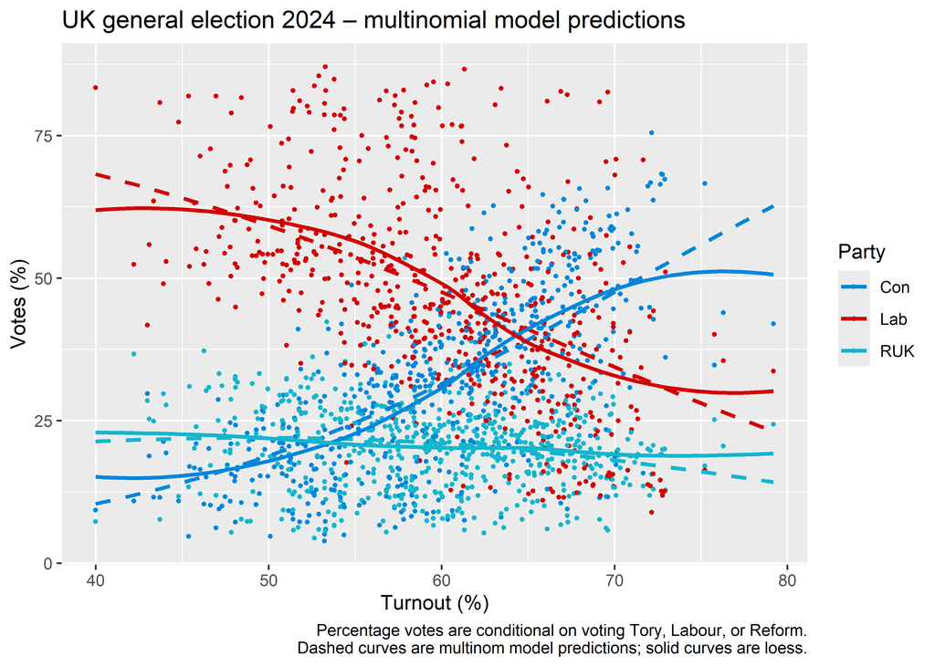

```r
plot_votes +
  geom_function(
    fun = \(x) pred_mod(x, "Lab"),
    colour = "#d50000",
    linewidth = 1,
    linetype = "dashed"
  ) +
  geom_function(
    fun = \(x) pred_mod(x, "Con"),
    colour = "#0087dc",
    linewidth = 1,
    linetype = "dashed"
  ) +
  geom_function(
    fun = \(x) pred_mod(x, "RUK"),
    colour = "#12b6cf",
    linewidth = 1,
    linetype = "dashed"
  ) +
  labs(title = "UK general election 2024 – multinomial model predictions",
       caption = "Percentage votes are conditional on voting Tory, Labour, or Reform.\nDashed curves are multinom model predictions; solid curves are loess.") +
  geom_smooth(se = FALSE,
              method = "loess",
              formula = y ~ x)
```

Same issue as for the colm model that the predictions aren’t sufficiently s-shaped, which is unsurprising given how similar the coefficients are.

Try lobbing a third degree polynomial at it:

```r
mn_mod_2 <- multinom(cbind(Con, Lab, RUK) ~ poly(turnout_percentage, 3),
                     Hess = TRUE,
                     data = for_analy_counts)
```

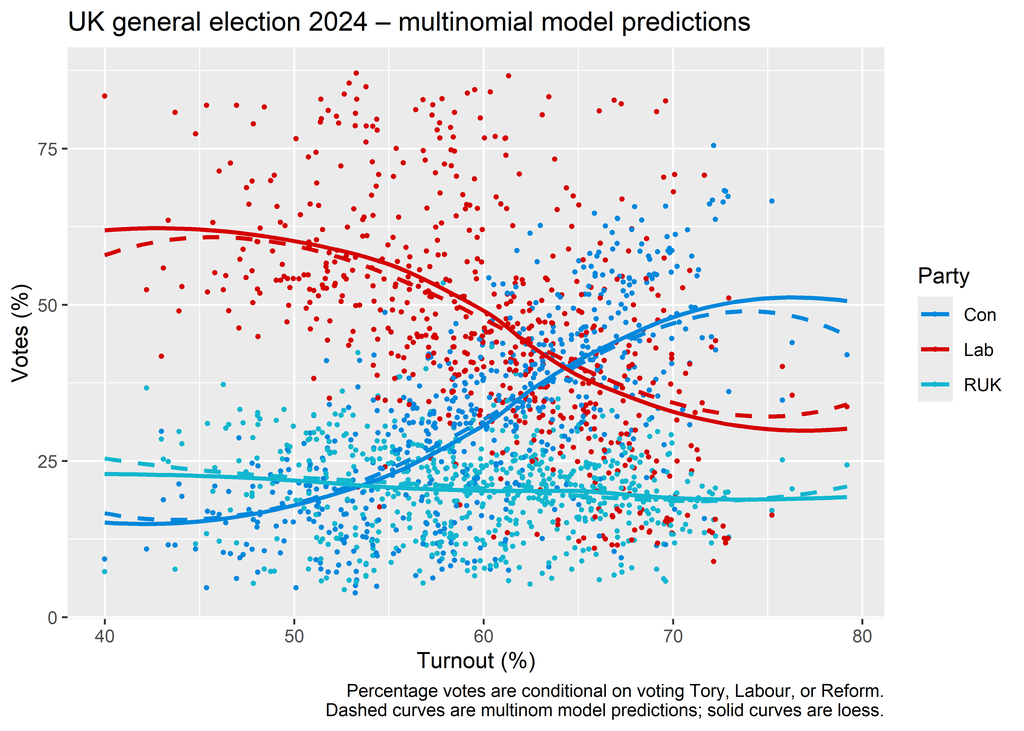

```r
pred_mod_2 <- Vectorize(function(turnout, party) {
  pred_matrix <- predict(mn_mod_2,
                         newdat = data.frame(turnout_percentage = turnout),
                         type = "probs") |> as.matrix()

  pred_matrix[party, ] |>
    as.vector() * 100
})

plot_votes +
  geom_function(
    fun = \(x) pred_mod_2(x, "Lab"),
    colour = "#d50000",
    linewidth = 1,
    linetype = "dashed"
  ) +
  geom_function(
    fun = \(x) pred_mod_2(x, "Con"),
    colour = "#0087dc",
    linewidth = 1,
    linetype = "dashed"
  ) +
  geom_function(
    fun = \(x) pred_mod_2(x, "RUK"),
    colour = "#12b6cf",
    linewidth = 1,
    linetype = "dashed"
  ) +
  labs(title = "UK general election 2024 – multinomial model predictions", caption = "Percentage votes are conditional on voting Tory, Labour, or Reform.\nDashed curves are multinom model predictions; solid curves are loess.") +
  geom_smooth(se = FALSE,
              method = "loess",
              formula = y ~ x)
```

```r
mn_mod_2
```

```
## Call:
## multinom(formula = cbind(Con, Lab, RUK) ~ poly(turnout_percentage,
##     3), data = for_analy_counts, Hess = TRUE)
##
## Coefficients:
##     (Intercept) poly(turnout_percentage, 3)1 poly(turnout_percentage, 3)2
## Lab   0.4148995                   -12.329299                   -0.1413748
## RUK  -0.4008138                    -9.463173                    0.6312236
##     poly(turnout_percentage, 3)3
## Lab                     1.757868
## RUK                     1.306942
##
## Residual Deviance: 41049268
## AIC: 41049284
```

## What effect does having a Reform candidate have on the split between Tory/Labour?

They stood most places, so this is going to be tricky…

```r
reform_ass <- simp_dat |>
  drop_na(Lab, Con, turnout_percentage) |>
  mutate(reform_stood = 1 - is.na(RUK),
         Lab_perc = 100 * Lab / (Lab + Con))
```

```r
table1(~ Lab + Con + RUK + reform_stood + turnout_percentage, data = reform_ass)
```

|  | Overall (N=630) |
| --- | --- |
| Lab |  |
| Mean (SD) | 15400 (5680) |
| Median [Min, Max] | 16200 [1490, 29200] |
| Con |  |
| Mean (SD) | 10800 (5520) |
| Median [Min, Max] | 11500 [586, 25500] |
| RUK |  |
| Mean (SD) | 6750 (2750) |
| Median [Min, Max] | 7050 [697, 21200] |
| Missing | 22 (3.5%) |
| reform_stood |  |
| Mean (SD) | 0.965 (0.184) |
| Median [Min, Max] | 1.00 [0, 1.00] |
| turnout_percentage |  |
| Mean (SD) | 59.9 (6.93) |
| Median [Min, Max] | 60.3 [40.0, 79.2] |

Where they didn’t stand:

```r
reform_ass |>
  dplyr::filter(reform_stood == 0) |>
  arrange(-Lab_perc) |>
  select(-c(RUK, reform_stood)) |>
  print(n = Inf)
```

```
## # A tibble: 22 × 5
##    constituency                            Con   Lab turnout_percentage Lab_perc
##    <chr>                                 <dbl> <dbl>              <dbl>    <dbl>
##  1 Sheffield Central                      2339 16569               52.5     87.6
##  2 Blaenau Gwent and Rhymney              3776 16027               42.7     80.9
##  3 Oxford East                            4739 19541               54.8     80.5
##  4 Leeds South                            4172 17117               41.7     80.4
##  5 Sheffield Heeley                       5242 21230               52.3     80.2
##  6 Sheffield Brightside and Hillsborough  4069 16301               44.9     80.0
##  7 Cambridge                              5073 19614               59.9     79.5
##  8 Sheffield Hallam                       6205 23875               70.8     79.4
##  9 Bristol East                           6435 20748               60.7     76.3
## 10 Sheffield South East                   6252 18710               48.2     75.0
## 11 Doncaster North                        7105 16231               44.4     69.6
## 12 Brighton Kemptown and Peacehaven       8230 17893               59.2     68.5
## 13 Hexham                                20275 23988               67.8     54.2
## 14 Earley and Woodley                    17361 18209               62.4     51.2
## 15 Middlesbrough South and East Clevela… 16254 16468               54.1     50.3
## 16 Stone, Great Wyrley and Penkridge     19880 14414               59.8     42.0
## 17 Epping Forest                         18038 12356               57.8     40.7
## 18 East Grinstead and Uckfield           19319 10440               66.8     35.1
## 19 Maidenhead                            18932  5766               66.5     23.3
## 20 Mid Dorset and North Poole            20090  4566               65.8     18.5
## 21 West Dorset                           19210  3086               69.3     13.8
## 22 Cheltenham                            17866  2665               65.1     13.0
```

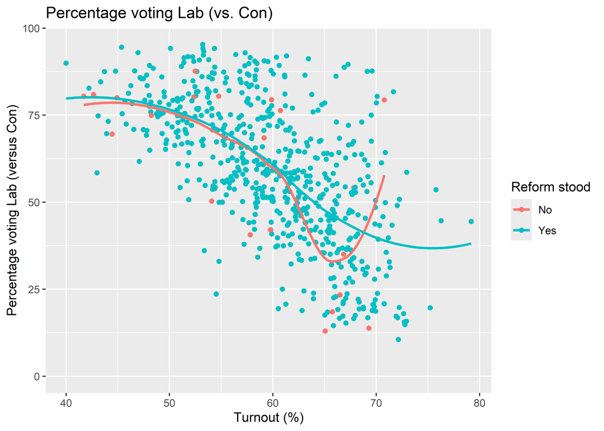

```r
reform_ass |>
  ggplot(aes(
    colour = factor(reform_stood, labels = c("No", "Yes")),
    x = turnout_percentage,
    y = Lab_perc
  )) +
  geom_point() +
  geom_smooth(method = "loess",
              formula = "y ~ x",
              se = FALSE) +
  labs(x = "Turnout (%)",
       y = "Percentage voting Lab (versus Con)",
       colour = "Reform stood",
       title = "Percentage voting Lab (vs. Con)") +
  ylim(0, NA)
```

Not enough data to have faith in this!

## Turnout and unemployment (as another index of deprivation)

```r
unemployment_june_dat <- read_csv("unemployment_benefit_june_2024.csv")
unemployment_june_dat
```

| Constituency | Number | Percent |
| --- | --- | --- |
| Aberafan Maesteg | 2055 | 3.657104 |
| Aberdeen North | 2770 | 3.528078 |
| Aberdeen South | 2220 | 2.932009 |
| Aberdeenshire North and Moray East | 1510 | 2.514404 |
| Airdrie and Shotts | 2085 | 3.414826 |
| Aldershot | 2195 | 2.837485 |
| Aldridge-Brownhills | 1620 | 2.907301 |
| Alloa and Grangemouth | 1905 | 3.210684 |
| Altrincham and Sale West | 1215 | 2.005948 |
| Alyn and Deeside | 1770 | 2.796495 |

[output cut: 640 more lines]

```r
summary(unemployment_june_dat)
```

```
##  Constituency           Number         Percent
##  Length:650         Min.   :  275   Min.   : 1.259
##  Class :character   1st Qu.: 1455   1st Qu.: 2.443
##  Mode  :character   Median : 2012   Median : 3.238
##                     Mean   : 2560   Mean   : 3.768
##                     3rd Qu.: 3119   3rd Qu.: 4.546
##                     Max.   :14150   Max.   :14.919
```

```r
vote_unemp <- left_join(simp_dat,
                        unemployment_june_dat |>
                          rename(constituency = "Constituency",
                                 unemp_percent = "Percent") |>
                          select(-Number))
```

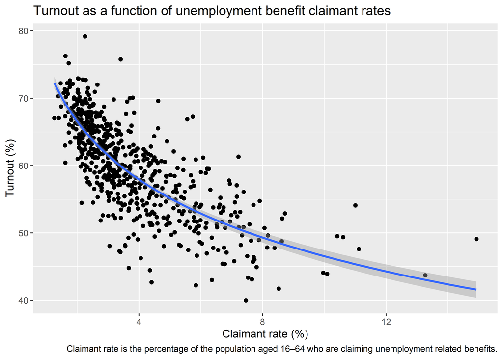

```r
vote_unemp |>
  ggplot(aes(y = turnout_percentage, x = unemp_percent)) +
  geom_point() +
  geom_smooth(method = lm, formula = y ~ log(x), se = TRUE) +
  labs(y = "Turnout (%)",
       x = "Claimant rate (%)",
       caption = "Claimant rate is the percentage of the population aged 16–64 who are claiming unemployment related benefits.",
       title = "Turnout as a function of unemployment benefit claimant rates")
```

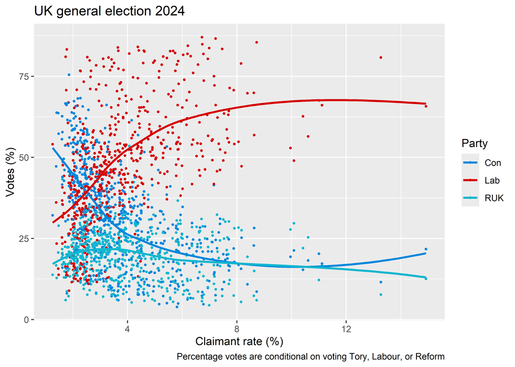

```r
left_join(
  perc,
  unemployment_june_dat |>
    rename(constituency = "Constituency", unemp_percent = "Percent") |>
    select(-Number)
) |>
  ggplot(aes(unemp_percent, Perc, colour = Party)) +
  geom_point(size = .7) +
  labs(
    x = "Claimant rate (%)",
    y = "Votes (%)",
    title = "UK general election 2024",
    caption = "Percentage votes are conditional on voting Tory, Labour, or Reform"
  ) +
  scale_color_manual(values = c("#0087dc", "#d50000", "#12b6cf")) +
  geom_smooth(se = FALSE,
              method = "loess",
              formula = y ~ x,
              span = .8)
```

```r
mn_tout_unemp <- multinom(
  cbind(Con, Lab, RUK) ~ turnout_percentage + log(unemp_percent) ,
  Hess = TRUE,
  data = vote_unemp
)
mn_tout_unemp |> summary()
```

```
## Call:
## multinom(formula = cbind(Con, Lab, RUK) ~ turnout_percentage +
##     log(unemp_percent), data = vote_unemp, Hess = TRUE)
##
## Coefficients:
##     (Intercept) turnout_percentage log(unemp_percent)
## Lab    2.501812        -0.04629887          0.5595221
## RUK    3.666410        -0.06442263         -0.1713252
##
## Std. Errors:
##     (Intercept) turnout_percentage log(unemp_percent)
## Lab 0.009638597       0.0001263663        0.002005744
## RUK 0.011763838       0.0001544506        0.002472342
##
## Residual Deviance: 40825101
## AIC: 40825113
```

```r
mn_tout_unemp |> confint()
```

```
## , , Lab
##
##                          2.5 %     97.5 %
## (Intercept)         2.48292082  2.5207034
## turnout_percentage -0.04654655 -0.0460512
## log(unemp_percent)  0.55559093  0.5634533
##
## , , RUK
##
##                          2.5 %      97.5 %
## (Intercept)         3.64335379  3.68946719
## turnout_percentage -0.06472535 -0.06411992
## log(unemp_percent) -0.17617094 -0.16647954
```